# A Simple Interface To View Stock Prices

April 2, 2019

## Functionality

We built a simple [web app](https://mghalbasch.shinyapps.io/Data_Products_Final_Project/) that allows the user to input stock symbols and see how the price of that stock has changed over time. The basic functionality includes:

- A slider to choose what years to display
- An input box to type in the stock symbol
  - Web app checks that the symbol matches a stock before displaying it
- A button to reset the page to start over if desired

## Usage

- To get started, just type a stock symbol into the box and hit "Submit"!
- A graph will be displayed with the stock's price over the years chosen
- If you add another stock symbol, the graph will be updated to compare the two.
- To change the range of dates, just move the slider for the min and max years.

## Data Source

The data for this web app comes from Yahoo Finance, and is loaded in via the `quantmod` package.

```r
library(quantmod)
df <- getSymbols("GOOG", auto.assign = FALSE)
```

We also clean the data briefly using the code:

```r
df <- data.frame(df) %>% rownames_to_column("Date") %>%
        select(Date, GOOGL = ends_with("Close"))
```

## Example Plot

Finally we have an example of the kind of plot the web app produces. This is made with the `ggplot2` package.

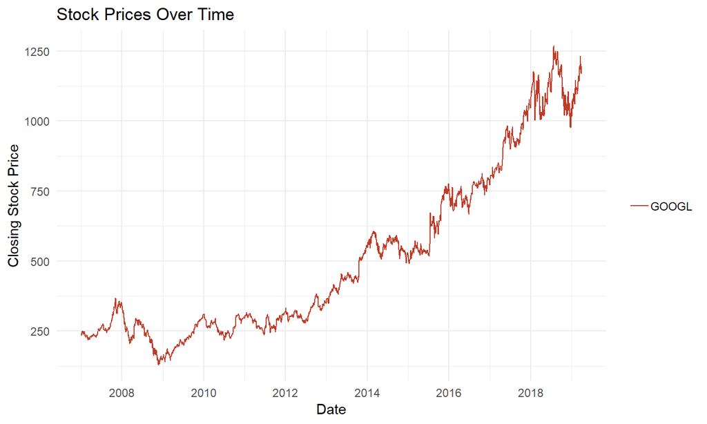